# Translate Story Map from English to Spanish

### Imports

```python
from arcgis import GIS
from bs4 import BeautifulSoup
from arcgis.learn.text import TextTranslator
```

### Connect to GIS and clone Story Map

```python
agol = GIS()
gis = GIS('home')
```

```python
storymapitem = agol.content.get('c8eef2a96c88489c92010a63d0944881')
storymapitem
```

[figure not shown]

[**South Pleasant Valley Road**](https://www.arcgis.com/home/item.html?id=c8eef2a96c88489c92010a63d0944881)  
(Cesar Chavez Street to Elmont Drive)

[figure not shown]

StoryMap by ATD_Publisher  
Last Modified: September 08, 2020  
0 comments, 2,332 views

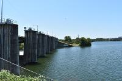

[**South Pleasant Valley Road**](https://geosaurus.maps.arcgis.com/home/item.html?id=a5af5750f9d143238d72bac224f204fb)  
(Cesar Chavez Street to Elmont Drive)

[figure not shown]

StoryMap by arcgis_python  
Last Modified: December 07, 2020  
0 comments, 0 views

```python
cloned_items = gis.content.clone_items([storymapitem], search_existing_items=False)
cloned_item = cloned_items[0]
cloned_item
```

### Text translator model

```python
translator = TextTranslator(source_language='en', target_language='es')
```

We will also write some helper functions to help translate the content of story map into the desired language. The `replace` function is a recursive [2] function that accepts a json (story map item dictionary) object `obj` and applies the function `func` on the values `v` of the `keys` list passed in the `replace` function argument.

```python
def replace(obj, keys, func):
    return {k: replace(func(v) if k in keys else v, keys, func)
        for k,v in obj.items()} if isinstance(obj, dict) else obj
```

The `translate` function will translate the English `text` (passed in the function argument) into Spanish language. The story map text sometimes contain text wrapped inside HTML [3] tags. We will use `BeautifulSoup` library to get the non-HTML part of the input text content and use the `translator`'s `translate` method to translate the non-HTML part of the input text into desired language (Spanish in this case).

```python
def translate(text):
    if text == '':
        return text

    soup = BeautifulSoup(text, "html.parser")

    for txt in soup.find_all(text=True):

        translation = translator.translate(txt)[0]['translated_text'] if txt.strip() != '' else txt
        txt.string.replace_with(" " + translation + " ")

    return str(soup)
```

### Translate Story Map content

We will call the story map item's `get_data()` method to retrieves the data associated with the item.

```python
smdata = storymapitem.get_data()
```

The call to the above method will return a python dictionary containing the contents of the story map which we wish to translate. We wish to translate not only the `text` content of the story map but also things like `title`, `summary`, `captions`, etc. To do so we will call the `replace` function defined above with the desired arguments.

```python
result = replace(smdata, ['text', 'alt', 'title', 'summary', 'byline', 'caption', 'storyLogoAlt'], translate)
```

### Update cloned Story Map item

```python
cloned_item.update({'url': cloned_item.url.replace(storymapitem.id, cloned_item.id),
    'text': result,
    'title': translator.translate(storymapitem['title'])[0]['translated_text'],
    'description': translator.translate(storymapitem['description'])[0]['translated_text'],
    'snippet': translator.translate(storymapitem['snippet'])[0]['translated_text']})
```

100.00% [1/1 00:00<00:00]

100.00% [1/1 00:06<00:00]

100.00% [1/1 00:00<00:00]

```
True
```

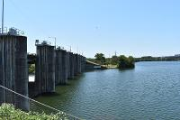

[**South Pleasant Valley Road**](https://geosaurus.maps.arcgis.com/home/item.html?id=a5af5750f9d143238d72bac224f204fb)  
(Cesar Chavez a Elmont Drive)

[figure not shown]

StoryMap by arcgis_python  
Last Modified: December 07, 2020  
0 comments, 0 views

```python
cloned_item
```